# Homework 6

**Due Date:** 2024-11-27 at 8:30 AM PT

**Name:** Joseph Matveyenko

## Preparation

### Connect to the server

You will want to connect to the server named **Jules**.

#### Mac / Linux: `ssh`

Apple and Linux machines have ssh protocols built into the operating system. You can access a remote server using the `ssh` command:

`ssh <server url / ip address>`

#### Windows: putty

Windows machines don’t have build in ssh. However, [PuTTY](https://www.putty.org) provides the same functionality. PuTTY provides a command line interface as well as a GUI.

#### VSCode (both Windows and Mac)

You can also use VSCode to ssh into an online server. To do this, you need the [Remote-SSH VSCode extension](https://marketplace.visualstudio.com/items?itemName=ms-vscode-remote.remote-ssh) (may or may not already be installed). To connect to a server in VSCode using ssh, access the VSCode command pallette (`ctrl + shift + P`) and type `ssh`. The `Remote-SSH: Connect to Host...` option will let you input a server to connect to.

## Set up Torch with Cuda

These instructions are from the [PyTorch installation instructions](https://pytorch.org/get-started/locally/). If CUDA is available, torch will probably find it when installing.

```
pip install torch
```

To see if CUDA is set, up, run:

```python
import torch

# Get cpu, gpu or mps device for training.
device = (
    "cuda"
    if torch.cuda.is_available()
    else "mps"
    if torch.backends.mps.is_available()
    else "cpu"
)
print(f"Using {device} device")
```

```
Using cuda device
```

## Homework - Neural Newtorks

Run your previous homework (HW_05) on the Jules ACS server. Do you observe any change in computation speed? Explain why you think the computation speed is faster/slower/the same as before?

1. Use a simple neural network to predict the number of per-capita COVID-19 deaths in each county in the US using the SVI variables. The outcome variable is `total_deaths_per_100k` and the predictor variables are `EP_POV150, EP_UNEMP, EP_HBURD, EP_NOHSDP, EP_UNINSUR, EP_AGE65, EP_AGE17, EP_DISABL, EP_SNGPNT, EP_LIMENG, EP_MINRTY, EP_MUNIT, EP_MOBILE, EP_CROWD, EP_NOVEH, EP_GROUPQ, EP_NOINT`. The neural network should have one hidden layer with 10 nodes and use the ReLU activation function. Plot the predicted values against the true values. What is the mean squared error of the predictions in the test set?

Loading in the data

```python
import os
import pandas as pd

# set working dir to main
if (os.getcwd().split(os.sep)[-1]) == 'homework':
    os.chdir(os.pardir)

# load pre-processed data and ensure FIPS is read as a string
dat_path = "data/processed/svi_covid.csv"
svi_covid = pd.read_csv(dat_path, dtype={'fips_code': str}).drop('Unnamed: 0', axis=1).dropna()
svi_covid.head(5)
```

|  | fips_code | total_cases_per_100k | total_deaths_per_100k | E_TOTPOP | EP_POV150 | EP_UNEMP | EP_HBURD | EP_NOHSDP | EP_UNINSUR | EP_AGE65 | ... | EP_DISABL | EP_SNGPNT | EP_LIMENG | EP_MINRTY | EP_MUNIT | EP_MOBILE | EP_CROWD | EP_NOVEH | EP_GROUPQ | EP_NOINT |
| --- | --- | --- | --- | --- | --- | --- | --- | --- | --- | --- | --- | --- | --- | --- | --- | --- | --- | --- | --- | --- | --- |
| 0 | 01001 | 33888.123075 | 399.925120 | 58761 | 20.2 | 2.8 | 19.7 | 9.6 | 7.4 | 15.6 | ... | 16.4 | 5.6 | 0.4 | 27.4 | 3.9 | 15.6 | 1.4 | 4.0 | 0.9 | 10.9 |
| 1 | 01003 | 30212.064090 | 313.169394 | 233420 | 18.3 | 3.4 | 23.2 | 8.4 | 9.3 | 21.2 | ... | 13.9 | 4.2 | 0.8 | 17.7 | 16.6 | 10.2 | 1.9 | 2.3 | 1.5 | 10.9 |
| 2 | 01005 | 30477.951521 | 418.056840 | 24877 | 37.7 | 5.8 | 25.1 | 23.5 | 10.7 | 19.8 | ... | 18.1 | 11.3 | 2.0 | 55.4 | 1.4 | 29.2 | 3.8 | 11.7 | 12.0 | 31.8 |
| 3 | 01007 | 36623.073120 | 498.853984 | 22251 | 29.0 | 8.7 | 23.2 | 21.1 | 8.4 | 16.8 | ... | 19.6 | 7.2 | 0.3 | 25.8 | 2.7 | 30.6 | 1.3 | 7.5 | 6.4 | 20.2 |
| 4 | 01009 | 31944.750072 | 441.796300 | 59077 | 22.9 | 6.0 | 19.4 | 18.2 | 10.2 | 18.3 | ... | 17.0 | 5.3 | 2.2 | 14.3 | 0.9 | 23.9 | 2.3 | 4.8 | 1.0 | 16.9 |

5 rows × 21 columns

Run a simple neural net using code by Gabe Hassler (PyTorch)

```python
# load packages
import torch
from torch import nn
from torch.utils.data import random_split
from torch.utils.data import DataLoader, Dataset
import numpy as np


torch.manual_seed(666) # for reproducibility

# special PyTorch class for loading data
class PandasDataset(Dataset):
    def __init__(self, dataframe, predictors, outcome):
        x = np.array(dataframe[predictors].values).reshape(-1, len(predictors))
        y = np.array(dataframe[outcome].values).reshape(-1, 1)
        self.x = torch.tensor(x, dtype=torch.float32)
        self.y = torch.tensor(y, dtype=torch.float32)

    def __len__(self):
        return len(self.x)

    def __getitem__(self, idx):
        return self.x[idx], self.y[idx]

# normalize and load data into class
def standardize_dataframe(df):
    means = df.mean()
    std_devs = df.std()
    return (df - means) / std_devs

outcome = svi_covid.columns[2]
predictors = 'EP_POV150, EP_UNEMP, EP_HBURD, EP_NOHSDP, EP_UNINSUR, EP_AGE65, EP_AGE17, EP_DISABL, EP_SNGPNT, EP_LIMENG, EP_MINRTY, EP_MUNIT, EP_MOBILE, EP_CROWD, EP_NOVEH, EP_GROUPQ, EP_NOINT'.split(', ')
svi_covid[predictors] = standardize_dataframe(svi_covid[predictors])
svi_covid[outcome] = (svi_covid[outcome] - svi_covid[outcome].mean()) / svi_covid[outcome].std()
dataset = PandasDataset(svi_covid, predictors, outcome)

# split into training and test sets
train_perc = 0.8 # 80% of the data will be used for training
train_size = int(train_perc * len(dataset))
test_size = len(dataset) - train_size
train_dataset, test_dataset = random_split(dataset, [train_size, test_size])

# where/how will the code run?
device = (
    "cuda"
    if torch.cuda.is_available()
    else "mps"
    if torch.backends.mps.is_available()
    else "cpu"
)
print(f"Using {device} device")

# define neural net
class NeuralNetwork(nn.Module):
    def __init__(self):
        super().__init__()
        self.linear_relu_stack = nn.Sequential(
            nn.Linear(len(predictors), 10), # the first number is the number of input features
            nn.ReLU(),
            nn.Linear(10, 1), # the second number is the number of output features
        )

    def forward(self, x):
        estimates = self.linear_relu_stack(x)
        return estimates

model = NeuralNetwork().to(device) # load the model onto the appropriate device

# define loss function
loss_fn = nn.MSELoss()

# define optimizer
optimizer = torch.optim.SGD(model.parameters(), lr=1e-3)

def train(dataloader, model, loss_fn, optimizer, losses):
    size = len(dataloader.dataset)
    num_batches = len(dataloader)
    model.train()
    train_loss = 0
    for batch, (X, y) in enumerate(dataloader):
        X, y = X.to(device), y.to(device)

        # Compute prediction error
        pred = model(X)
        loss = loss_fn(pred, y)

        # Backpropagation
        loss.backward()
        optimizer.step()
        optimizer.zero_grad()

        train_loss += loss.item()
    train_loss /= num_batches
    losses.append(train_loss)

def test(dataloader, model, loss_fn, losses):
    size = len(dataloader.dataset)
    num_batches = len(dataloader)
    model.eval()
    test_loss = 0
    with torch.no_grad():
        for X, y in dataloader:
            X, y = X.to(device), y.to(device)
            pred = model(X)
            test_loss += loss_fn(pred, y).item()
    test_loss /= num_batches
    losses.append(test_loss)
```

```
Using cuda device
```

Now, we can train the neural network.

```python
import time
batch_size = 400 # number of observations to use in each iteration
train_loader = DataLoader(train_dataset, batch_size=batch_size, shuffle=True)
test_loader = DataLoader(test_dataset, batch_size=batch_size, shuffle=True)

train_losses = []
test_losses = []

epochs = 700 # you will want to play with this number

t0 = time.time()
for t in range(epochs):
    train(train_loader, model, loss_fn, optimizer, train_losses)
    test(test_loader, model, loss_fn, test_losses)
t1 = time.time()
elapsed = t1-t0
print(f"Done! Elapsed time = {elapsed:.2f} seconds")
```

```
Done! Elapsed time = 16.89 seconds
```

Next, we plot the losses

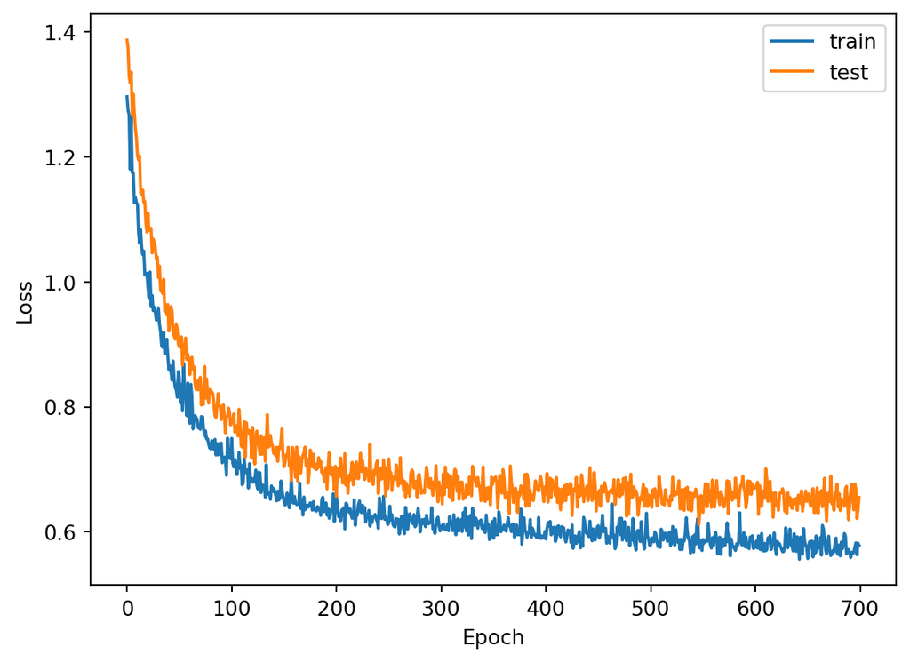

```python
import matplotlib.pyplot as plt

plt.plot(train_losses, label="train")
plt.plot(test_losses, label="test")
plt.legend()
plt.xlabel("Epoch")
plt.ylabel("Loss")
plt.show()
```

and plot the predicted values against the true values and calculate mean squared error

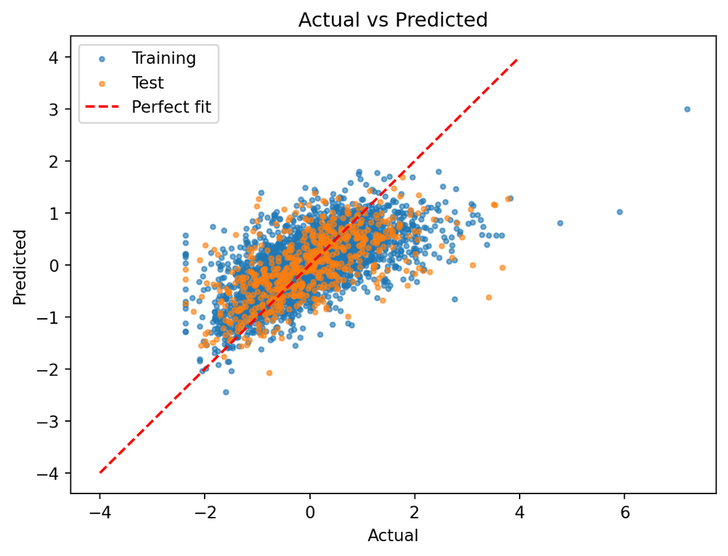

```
Mean Squared Error of the test set predictions: 0.650
```

```python
import torch
import numpy as np
import matplotlib.pyplot as plt

# extract test/train from dataset
x_train = torch.cat([x.unsqueeze(0) for x, y in train_dataset], dim=0)
y_train = torch.cat([y.unsqueeze(0) for x, y in train_dataset], dim=0)

x_test = torch.cat([x.unsqueeze(0) for x, y in test_dataset], dim=0)
y_test = torch.cat([y.unsqueeze(0) for x, y in test_dataset], dim=0)

# move data to device
x_train, y_train = x_train.to(device), y_train.to(device)
x_test, y_test = x_test.to(device), y_test.to(device)

# make predictions
with torch.no_grad():
    y_train_pred = model(x_train).cpu().numpy()
    y_test_pred = model(x_test).cpu().numpy()

# convert true values to numpy
y_train = y_train.cpu().numpy()
y_test = y_test.cpu().numpy()

# plot results
plt.scatter(y_train, y_train_pred, label="Training", alpha=0.6, s=8)
plt.scatter(y_test, y_test_pred, label="Test", alpha=0.6, s=8)
plt.plot(np.linspace(-4, 4, 2), np.linspace(-4, 4, 2), 'r--', label='Perfect fit')
plt.xlabel("Actual")
plt.ylabel("Predicted")
plt.legend()
plt.title("Actual vs Predicted")
plt.show()

print(f"Mean Squared Error of the test set predictions: {np.mean((y_test - y_test_pred)**2):.3f}")
```

2. Repeat the analysis from the previous question, but this time use a more complicated neural network with more hidden layers and/or more nodes in the hidden layers. You should experiment with different architectures and activation functions to see what works best. Plot the predicted values against the true values. What is the mean squared error of the predictions in the test set?

Define a new neural network with more complexity and run on the same dataset

```python
torch.manual_seed(666) # for reproducibility

# load data into class
dataset = PandasDataset(svi_covid, predictors, outcome)

# split into training and test sets
train_perc = 0.8 # 80% of the data will be used for training
train_size = int(train_perc * len(dataset))
test_size = len(dataset) - train_size
train_dataset, test_dataset = random_split(dataset, [train_size, test_size])

# where/how will the code run?
device = (
    "cuda"
    if torch.cuda.is_available()
    else "mps"
    if torch.backends.mps.is_available()
    else "cpu"
)
print(f"Using {device} device")

# define neural net
class NeuralNetwork(nn.Module):
    def __init__(self):
        super().__init__()
        self.linear_relu_stack = nn.Sequential(
            nn.Linear(len(predictors), 10), # the first number is the number of input features
            nn.Tanh(),
            nn.Linear(10, 50),
            nn.Tanh(),
            nn.Linear(50, 10),
            nn.Tanh(),
            nn.Linear(10, 10),
            nn.ReLU(),
            nn.Linear(10, 1), # the second number is the number of output features
        )

    def forward(self, x):
        estimates = self.linear_relu_stack(x)
        return estimates

model = NeuralNetwork().to(device) # load the model onto the appropriate device

# define loss function
loss_fn = nn.MSELoss()

# define optimizer
optimizer = torch.optim.SGD(model.parameters(), lr=1e-3)

def train(dataloader, model, loss_fn, optimizer, losses):
    size = len(dataloader.dataset)
    num_batches = len(dataloader)
    model.train()
    train_loss = 0
    for batch, (X, y) in enumerate(dataloader):
        X, y = X.to(device), y.to(device)

        # Compute prediction error
        pred = model(X)
        loss = loss_fn(pred, y)

        # Backpropagation
        loss.backward()
        optimizer.step()
        optimizer.zero_grad()

        train_loss += loss.item()
    train_loss /= num_batches
    losses.append(train_loss)

def test(dataloader, model, loss_fn, losses):
    size = len(dataloader.dataset)
    num_batches = len(dataloader)
    model.eval()
    test_loss = 0
    with torch.no_grad():
        for X, y in dataloader:
            X, y = X.to(device), y.to(device)
            pred = model(X)
            test_loss += loss_fn(pred, y).item()
    test_loss /= num_batches
    losses.append(test_loss)
```

```
Using cuda device
```

Train on the training data

```python
batch_size = 400 # number of observations to use in each iteration
train_loader = DataLoader(train_dataset, batch_size=batch_size, shuffle=True)
test_loader = DataLoader(test_dataset, batch_size=batch_size, shuffle=True)

train_losses = []
test_losses = []

epochs = 1900 # you will want to play with this number

t0 = time.time()
for t in range(epochs):
    train(train_loader, model, loss_fn, optimizer, train_losses)
    test(test_loader, model, loss_fn, test_losses)
t1 = time.time()
elapsed = t1-t0
print(f"Done! Elapsed time = {elapsed:.2f} seconds")
```

```
Done! Elapsed time = 51.64 seconds
```

Plot the results and mean squared error

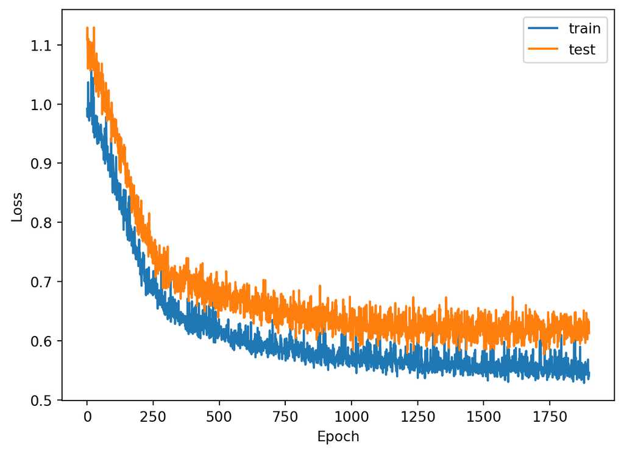

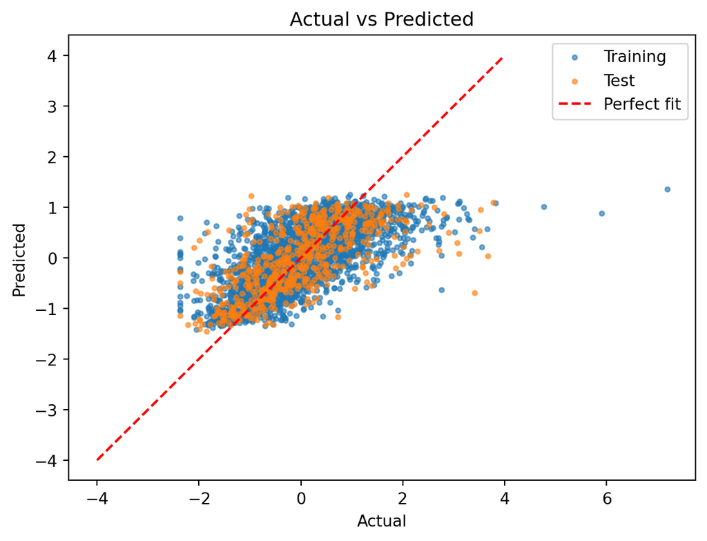

```
Mean Squared Error of the test set predictions: 0.621
```

```python
plt.plot(train_losses, label="train")
plt.plot(test_losses, label="test")
plt.legend()
plt.xlabel("Epoch")
plt.ylabel("Loss")
plt.show()

# extract test/train from dataset
x_train = torch.cat([x.unsqueeze(0) for x, y in train_dataset], dim=0)
y_train = torch.cat([y.unsqueeze(0) for x, y in train_dataset], dim=0)

x_test = torch.cat([x.unsqueeze(0) for x, y in test_dataset], dim=0)
y_test = torch.cat([y.unsqueeze(0) for x, y in test_dataset], dim=0)

# move data to device
x_train, y_train = x_train.to(device), y_train.to(device)
x_test, y_test = x_test.to(device), y_test.to(device)

# make predictions
with torch.no_grad():
    y_train_pred = model(x_train).cpu().numpy()
    y_test_pred = model(x_test).cpu().numpy()

# convert true values to numpy
y_train = y_train.cpu().numpy()
y_test = y_test.cpu().numpy()

# plot results
plt.scatter(y_train, y_train_pred, label="Training", alpha=0.6, s=8)
plt.scatter(y_test, y_test_pred, label="Test", alpha=0.6, s=8)
plt.plot(np.linspace(-4, 4, 2), np.linspace(-4, 4, 2), 'r--', label='Perfect fit')
plt.xlabel("Actual")
plt.ylabel("Predicted")
plt.legend()
plt.title("Actual vs Predicted")
plt.show()

print(f"Mean Squared Error of the test set predictions: {np.mean((y_test - y_test_pred)**2):.3f}")
```